# Reproducible Research: Peer Assessment 1

###### by: Ben M (4/8/2016)

# Introduction

This assignment makes use of data from a personal activity monitoring device. This device collects data at 5 minute intervals through out the day. The data consists of two months of data from an anonymous individual collected during the months of October and November, 2012 and include the number of steps taken in 5 minute intervals each day.

# Data

The data for this assignment can be downloaded from the course web site:

- Dataset: Activity monitoring data [52K]

The variables included in this dataset are:

- steps: Number of steps taking in a 5-minute interval (missing values are coded as NA)
- date: The date on which the measurement was taken in YYYY-MM-DD format
- interval: Identifier for the 5-minute interval in which measurement was taken

The dataset is stored in a comma-separated-value (CSV) file and there are a total of 17,568 observations in this dataset.

# Assignment

This assignment will be described in multiple parts. You will need to write a report that answers the questions detailed below. Ultimately, you will need to complete the entire assignment in a *single R markdown* document that can be processed by *knitr* and be transformed into an HTML file.

Throughout your report make sure you always include the code that you used to generate the output you present. When writing code chunks in the R markdown document, always use echo = TRUE so that someone else will be able to read the code. *This assignment will be evaluated via peer assessment so it is essential that your peer evaluators be able to review the code for your analysis.*

For the plotting aspects of this assignment, feel free to use any plotting system in R (i.e., base, lattice, ggplot2)

Fork/clone the [GitHub repository created for this assignment](https://github.com/rdpeng/RepData_PeerAssessment1). You will submit this assignment by pushing your completed files into your forked repository on GitHub. The assignment submission will consist of the URL to your GitHub repository and the SHA-1 commit ID for your repository state.

NOTE: The GitHub repository also contains the dataset for the assignment so you do not have to download the data separately.

# Loading and preparing Data

1. Load the data (i.e. read.csv())

```r
activityDataRaw <- read.csv("activity.csv",stringsAsFactors=FALSE)
```

2. Process/transform the data (if necessary) into a format suitable for your analysis.

```r
# Data formatting
activityDataRaw$date <- as.POSIXct(activityDataRaw$date, format="%Y-%m-%d")
activityDataRaw$interval <- as.factor(activityDataRaw$interval)
activityDataRaw <- data.frame(date=activityDataRaw$date
                              ,weekday=tolower(weekdays(activityDataRaw$date))
                              ,steps=activityDataRaw$steps
                              ,interval=activityDataRaw$interval
                              )
activityDataRaw <-cbind(activityDataRaw, daytype=ifelse(activityDataRaw$weekday=="saturday"|activityDataRaw$weekday=="sunday","weekend","weekday"))
# Clean Data
activityData <- data.frame(date=activityDataRaw$date
                           ,weekday=activityDataRaw$weekday
                           ,daytype=activityDataRaw$daytype
                           ,interval=activityDataRaw$interval
                           ,steps=activityDataRaw$steps)
# cleanup
rm(activityDataRaw)
# display sample data set
head(activityData)
```

```
##         date weekday daytype interval steps
## 1 2012-10-01  monday weekday        0    NA
## 2 2012-10-01  monday weekday        5    NA
## 3 2012-10-01  monday weekday       10    NA
## 4 2012-10-01  monday weekday       15    NA
## 5 2012-10-01  monday weekday       20    NA
## 6 2012-10-01  monday weekday       25    NA
```

# What is the mean total number of steps taken per day?

1. Make a histogram of the total number of steps taken each day

```r
# Derive total number of steps
sumData <- aggregate(steps ~ date, activityData, sum)
# Assign column names
names(sumData) <- c("data","steps")
# Show sample data
head(sumData)
```

```
##         data steps
## 1 2012-10-02   126
## 2 2012-10-03 11352
## 3 2012-10-04 12116
## 4 2012-10-05 13294
## 5 2012-10-06 15420
## 6 2012-10-07 11015
```

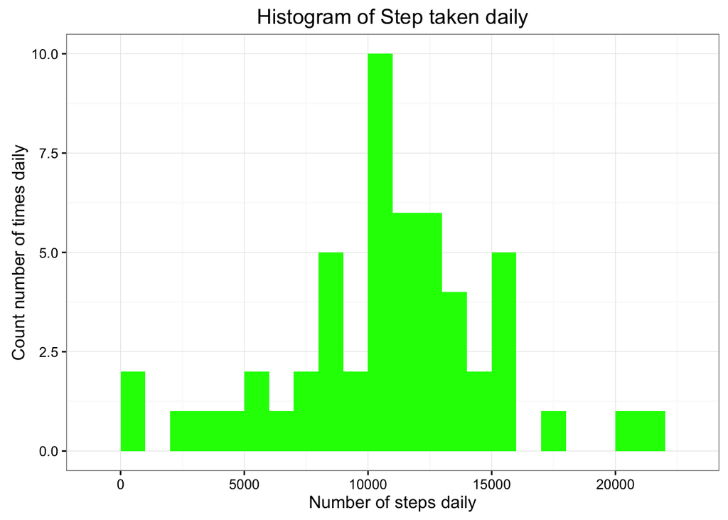

```r
# Plot the histogram using ggplot
library(ggplot2)
#png("plot1.png")
ggplot(sumData,aes(x=steps)) + geom_histogram(fill="green", binwidth=1000)+ labs(title="Histogram of Step taken daily", x="Number of steps daily", y= "Count number of times daily")+ theme_bw()
```

2. Calculate and report the mean and median total number of steps taken per day

```r
stepsMean<-mean(sumData$steps)
stepsMedian<-median(sumData$steps)
# showing the value of mean
mean(sumData$steps)
```

```
## [1] 10766.19
```

```r
#showing the value of median
median(sumData$steps)
```

```
## [1] 10765
```

# What is the average daily activity pattern?

1. Make a time series plot (i.e. type = “l”) of the 5-minute interval (x-axis) and the average number of steps taken, averaged across all days (y-axis)

```r
meanData <- aggregate(activityData$steps
                     ,by=list(activityData$interval)
                     ,FUN=mean
                     ,na.rm=TRUE)

names(meanData) <- c("interval","mean")
head(meanData)
```

```
##   interval      mean
## 1        0 1.7169811
## 2        5 0.3396226
## 3       10 0.1320755
## 4       15 0.1509434
## 5       20 0.0754717
## 6       25 2.0943396
```

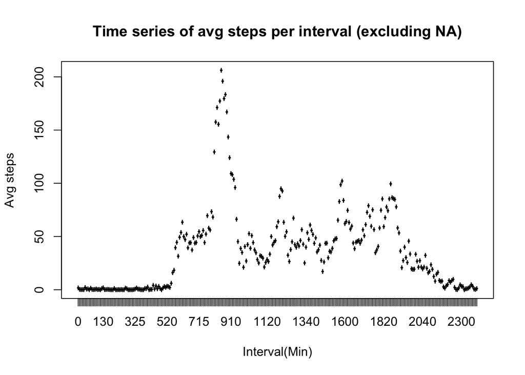

```r
#png("plot2.png")
plot(meanData$interval
     ,meanData$mean
     ,type="l"
     ,col="blue"
     ,lwd=2
     ,xlab="Interval(Min)"
     ,ylab="Avg steps"
     ,main="Time series of avg steps per interval (excluding NA)")
```

2. Which 5-minute interval, on average across all the days in the dataset, contains the maximum number of steps?

```r
maxPos <- which(meanData$mean == max(meanData$mean))
maxInterval <- meanData[maxPos,1]
#5min average across all days in the data set
which(meanData$mean == max(meanData$mean))
```

```
## [1] 104
```

```r
#5min maximum number of steps
meanData[maxPos,1]
```

```
## [1] 835
## 288 Levels: 0 5 10 15 20 25 30 35 40 45 50 55 100 105 110 115 120 ... 2355
```

# Inputing the missing values

1. Calculate and report the total number of missing values in the dataset (i.e. the total number of rows with NAs)

```r
#showing NA count
sum(is.na(activityData$steps))
```

```
## [1] 2304
```

2. Devise a strategy for filling in all of the missing values in the dataset. The strategy does not need to be sophisticated. For example, you could use the mean/median for that day, or the mean for that 5-minute interval, etc.

```r
# showing steps with na count
summary(is.na(activityData$steps))
```

```
##    Mode   FALSE    TRUE    NA's
## logical   15264    2304       0
```

```r
naPos <- which(is.na(activityData$steps))
meanVector <- rep(mean(activityData$steps, na.rm=TRUE), time=length(naPos))
```

3. Create a new dataset that is equal to the original dataset but with the missing data filled in.

```r
activityData[naPos,"steps"] <- meanVector

#showing NA are now filled
summary(is.na(activityData$steps))
```

```
##    Mode   FALSE    NA's
## logical   17568       0
```

4. Make a histogram of the total number of steps taken each day and Calculate and report the mean and median total number of steps taken per day. Do these values differ from the estimates from the first part of the assignment? What is the impact of imputing missing data on the estimates of the total daily number of steps?

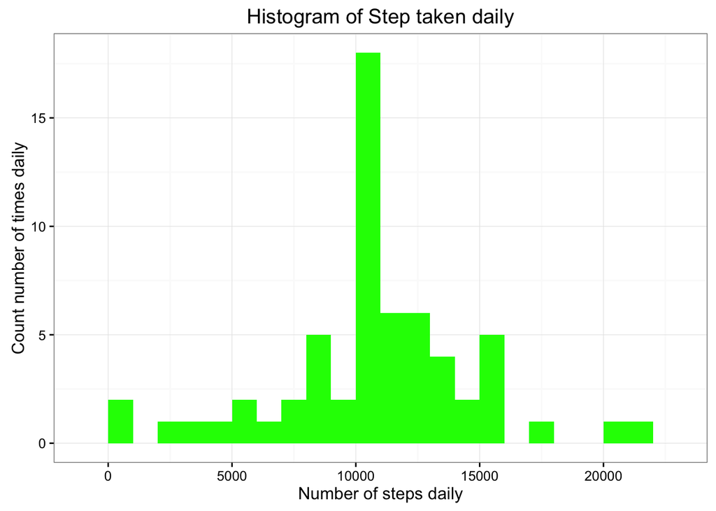

```r
sumData <- aggregate(activityData$steps, by=list(activityData$date),FUN=sum)
names(sumData) <-c("Date","steps")
#png("plot3.png")
ggplot(sumData,aes(x=steps)) + geom_histogram(fill="green", binwidth=1000)+ labs(title="Histogram of Step taken daily", x="Number of steps daily", y= "Count number of times daily")+ theme_bw()
```

```r
meanData<-mean(sumData$steps)
medianData<-median(sumData$steps)
meanData
```

```
## [1] 10766.19
```

```r
medianData
```

```
## [1] 10766.19
```

# Are there differences ina ctivity patterns between weekdays and weekends?

1. Create a new factor variable in the dataset with two levels – “weekday” and “weekend” indicating whether a given date is a weekday or weekend day.

```r
library(lattice)
head(activityData)
```

```
##         date weekday daytype interval   steps
## 1 2012-10-01  monday weekday        0 37.3826
## 2 2012-10-01  monday weekday        5 37.3826
## 3 2012-10-01  monday weekday       10 37.3826
## 4 2012-10-01  monday weekday       15 37.3826
## 5 2012-10-01  monday weekday       20 37.3826
## 6 2012-10-01  monday weekday       25 37.3826
```

```r
meanData<- aggregate(activityData$steps
                     ,by=list(activityData$daytype,activityData$weekday,activityData$interval),FUN=mean)
names(meanData) <- c("DayType","Weekday", "Interval", "Mean")
head(meanData)
```

```
##   DayType  Weekday Interval     Mean
## 1 weekday   friday        0 8.307244
## 2 weekday   monday        0 9.418355
## 3 weekend saturday        0 4.672825
## 4 weekend   sunday        0 4.672825
## 5 weekday thursday        0 9.375844
## 6 weekday  tuesday        0 0.000000
```

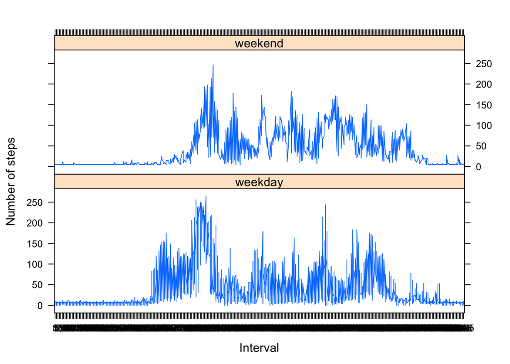

```r
#png("plot4.png")
xyplot(Mean ~ Interval | DayType , meanData
       ,type="l"
       ,lwd="1"
       ,xlab="Interval"
       ,ylab="Number of steps"
       ,layout=c(1,2))
```